# AirScan CI

Surveillance intelligente de la qualité de l’air sur le campus de l’UFHB

Published

January 1, 2026

# 1 AirScan CI

**Surveillance intelligente de la qualité de l’air — Campus UFHB Cocody · Abidjan · 2026**

# 2 Problématique

L’**Université Félix Houphouët-Boigny (UFHB)** de Cocody accueille chaque jour plus de **65 000 étudiants** sur un campus de **200 hectares** en plein cœur d’Abidjan. Si l’université offre un cadre académique de premier plan, la question de la **qualité de l’air** que respirent étudiants, enseignants et personnels reste largement ignorée.

Pourtant, les sources de pollution y sont multiples et quotidiennes :

- **Trafic automobile** intense aux heures de pointe au niveau du parking d’entrée
- **Émissions de cuisson** au Restaurant Universitaire (charbon, gaz)
- **Accumulation de CO₂** dans les amphithéâtres bondés lors des cours
- **Déchets organiques** dans les cités universitaires

Ces polluants — monoxyde de carbone (CO), dioxyde de carbone (CO₂) et ammoniac (NH₃) — ont des effets documentés sur la santé : fatigue, maux de tête, baisse de concentration, et à long terme, risques respiratoires chroniques.

**Aucun système de surveillance de la qualité de l’air n’existait sur le campus de l’UFHB avant ce projet.**

**AirScan CI** répond à ce vide en déployant une balise de mesure autonome sur le campus, collectant des données en temps réel, et en les rendant accessibles à tous via un tableau de bord interactif.

# 3 Le système AirScan

## 3.1 Architecture générale

Le système repose sur un pipeline en quatre étapes :

```
Balise physique  →  Réseau GPRS (SIM900)  →  Serveur  →  Dashboard Shiny
     ↓                                            ↓
 Capteurs MQ                              API Open-Meteo
 GPS · BMP180                          (Température · Humidité)
```

## 3.2 La balise de mesure

La balise a été **entièrement conçue et assemblée par l’équipe**. Elle est constituée des composants suivants :

| Composant | Rôle |
| --- | --- |
| **Arduino Mega 2560** | Cerveau — orchestre tous les capteurs |
| **MQ-135** | Mesure CO₂ et NH₃ |
| **MQ-7** | Mesure CO (monoxyde de carbone) |
| **BMP180 (GY-68)** | Pression atmosphérique et altitude |
| **GPS NEO-6M** | Géolocalisation de chaque mesure |
| **Module SIM900** | Transmission des données via GPRS |
| **Power bank** | Alimentation autonome sur le terrain |

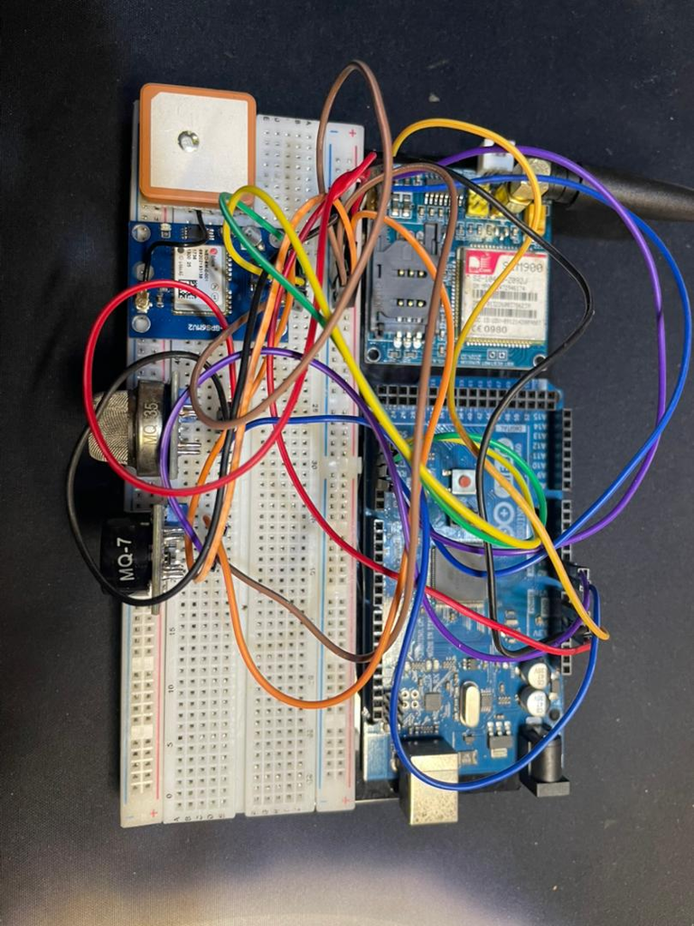

Vue d’ensemble de la balise

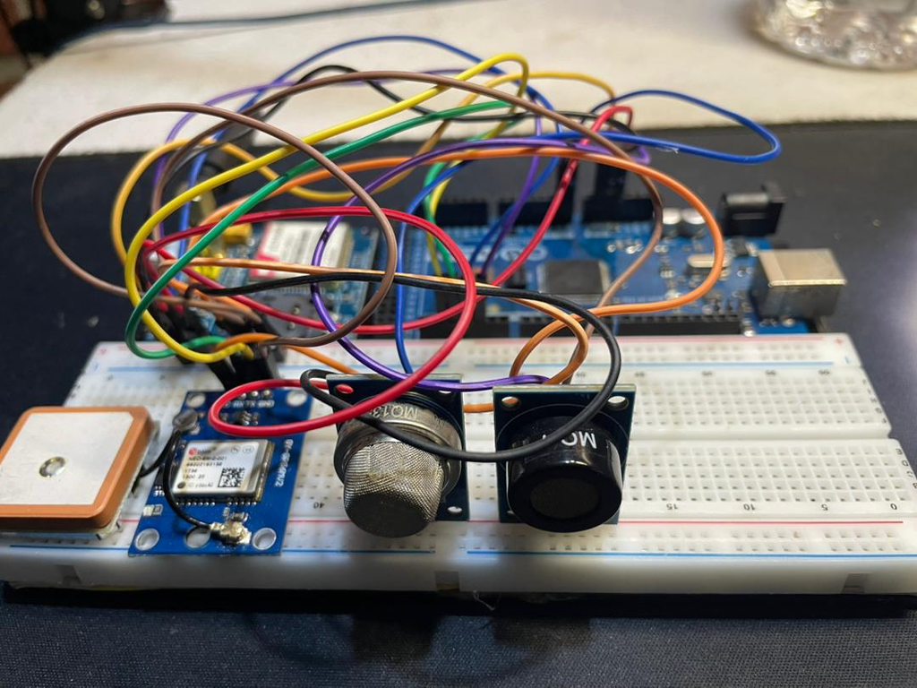

Détail des capteurs MQ-135 et MQ-7

> La température et l’humidité ne sont pas mesurées directement par la balise. Le serveur utilise les coordonnées GPS transmises par le module NEO-6M pour interroger l’**API Open-Meteo** et obtenir ces données météorologiques en temps réel.

## 3.3 Zones instrumentées

Cinq zones du campus ont été identifiées et instrumentées :

| Zone | AQI moyen | CO moy. (ppm) | CO₂ moy. (ppm) | NH₃ moy. (ppm) |
| --- | --- | --- | --- | --- |
| Amphithéâtres | 12.0 | 4.4 | 650 | 2.5 |
| Cités Univ. | 13.4 | 8.1 | 514 | 4.0 |
| Parking Entrée | 23.5 | 26.7 | 542 | 4.6 |
| Restaurant U. | 16.2 | 6.7 | 595 | 7.1 |
| Zone Verte | 6.2 | 1.7 | 392 | 0.8 |

# 4 Analyse des données

## 4.1 Indice de Qualité de l’Air (AQI) par zone

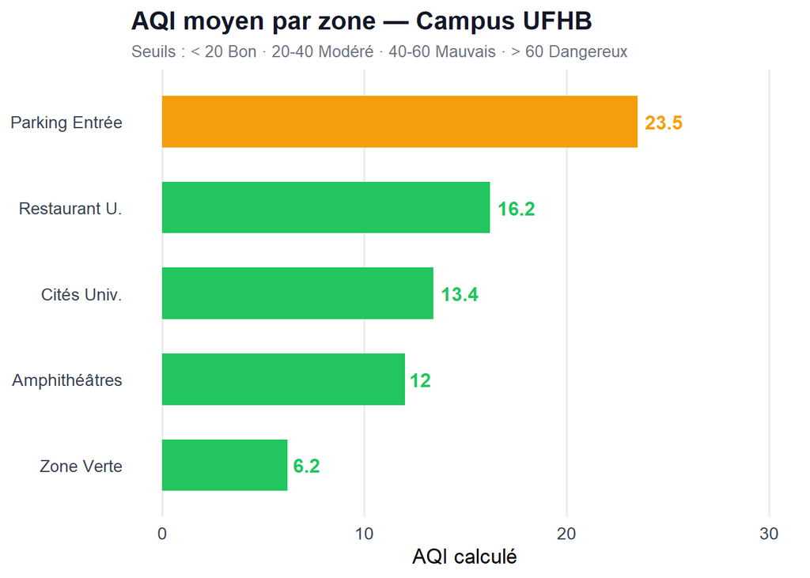

## 4.2 Évolution horaire des polluants

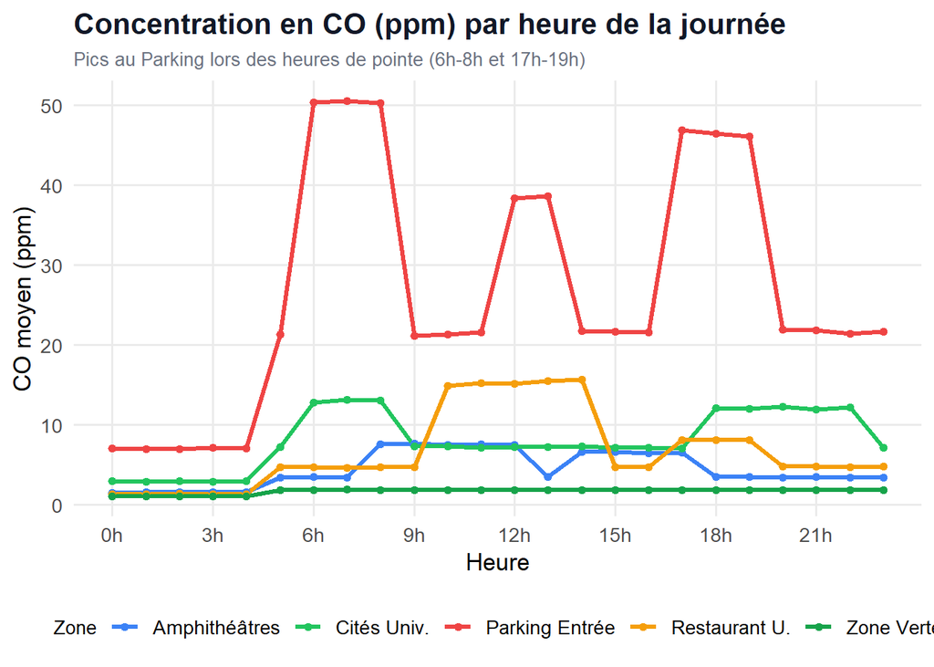

## 4.3 CO₂ dans les amphithéâtres — effet de la présence étudiante

[figure not shown]

## 4.4 Semaine vs Week-end

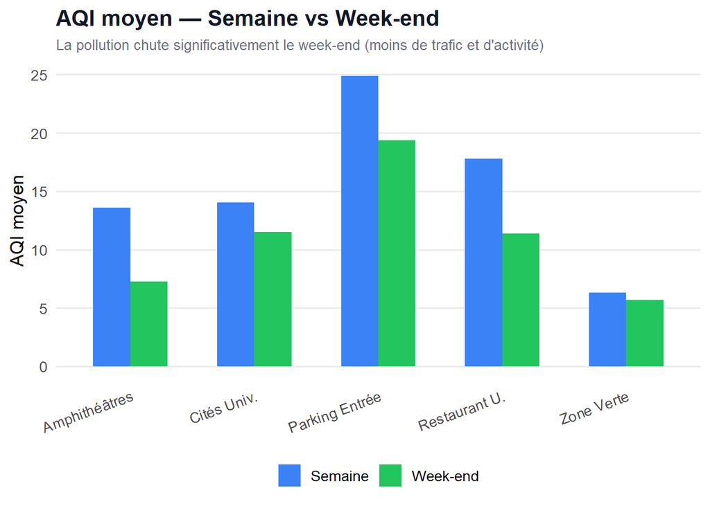

# 5 Le Dashboard

Le dashboard **AirScan CI** est une application web interactive développée avec **R Shiny**. Il permet de visualiser et d’analyser les données collectées par la balise en temps réel.

**Accès à l’application :** https://airscan.shinyapps.io/AirScan/

## 5.1 Pages disponibles

| Page | Description |
| --- | --- |
| **Accueil** | Page d’introduction animée |
| **Dashboard** | KPIs et vue d’ensemble par zone |
| **Carte** | Carte interactive du campus avec heatmap AQI |
| **Temporelle** | Évolution horaire et journalière par polluant |
| **Prédiction ML** | Prédiction de l’AQI par Random Forest |
| **Corrélations** | Matrice de corrélation entre variables |
| **Santé** | Score de risque respiratoire personnalisé |
| **Balise** | Présentation du dispositif matériel |
| **Équipe** | Membres du projet |

## 5.2 Stack technique

```
R / Shiny · shinydashboard · ggplot2 · Leaflet · randomForest · corrplot
Arduino C++ · Three.js · API Open-Meteo
```

# 6 L’équipe

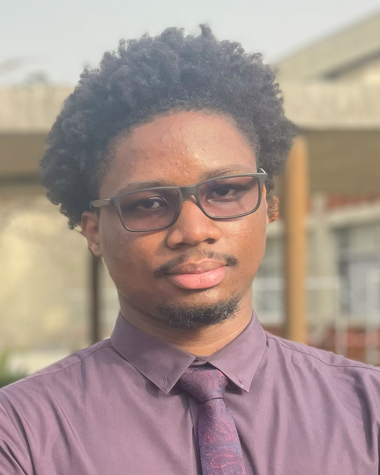

**Tape Doubahi Jean Christopher**

Licence MIAGE

Master 1 Data Science

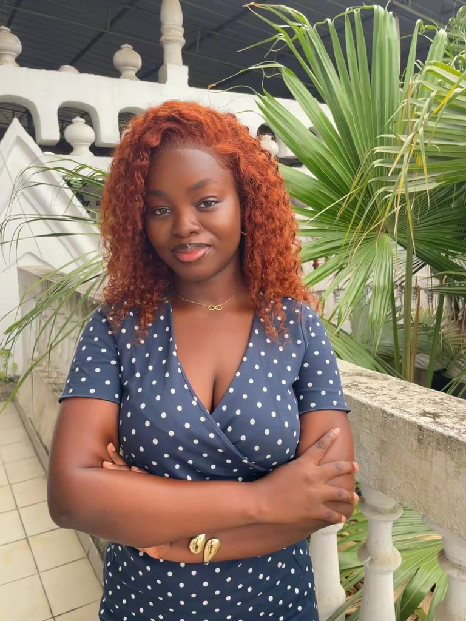

**Assamoi Armida Yassine**

Lic. Statistique & Économie Appl.

Master 1 Data Science

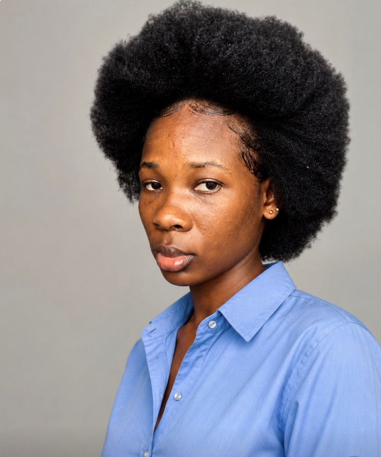

**Coulibaly Ramatou**

Lic. Statistique & Économie Appl.

Master 1 Data Science

> Projet encadré par le **Pr. Laurent Rouvière** UFR Mathématiques-Informatique · Université Félix Houphouët-Boigny de Cocody · 2025–2026